# Tugas 1

Kamilah Nurul Azizah

2023-09-04

```r
library(dplyr)
library(TTR)
library(forecast)
library(lmtest)
library(orcutt)
library(HoRM)
```

### Import Data

```r
library(rio)
data <- import("https://raw.githubusercontent.com/kamilahnrl/mpdw/main/Pertemuan%201/data.xlsx")
```

### membagi data menjadi training dan testing

```r
training<-data[1:256,2]
testing<-data[257:295,2]
training.ts<-ts(training)
testing.ts<-ts(testing)
```

### Eksplorasi Data

```r
View(data)
str(data)
```

```
## 'data.frame':    295 obs. of  2 variables:
##  $ No         : num  1 2 3 4 5 6 7 8 9 10 ...
##  $ BawangMerah: num  19300 18300 18000 18350 18500 ...
```

```r
dim(data)
```

```
## [1] 295   2
```

Mengubah data agar terbaca sebagai data deret waktu dengan fungsi `ts()`

```r
data.ts <- ts(data$BawangMerah)
summary(data.ts)
```

```
##    Min. 1st Qu.  Median    Mean 3rd Qu.    Max.
##   15900   25750   30000   30426   33700   72900
```

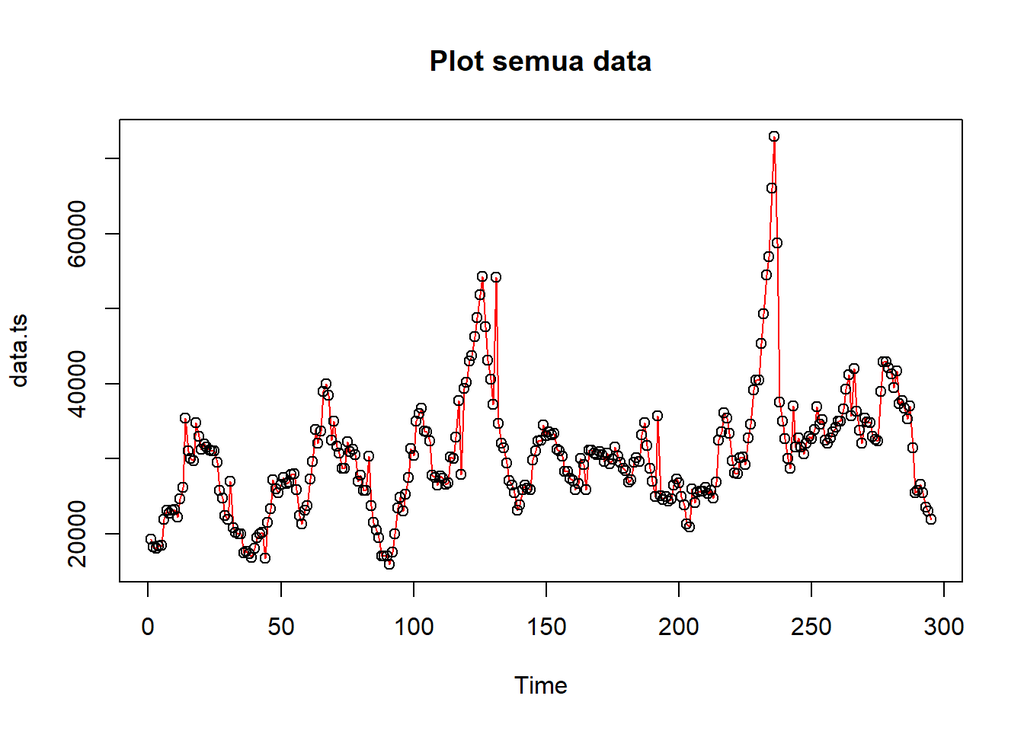

```r
#eksplorasi keseluruhan data
plot(data.ts, col="red",main="Plot semua data")
points(data.ts)
```

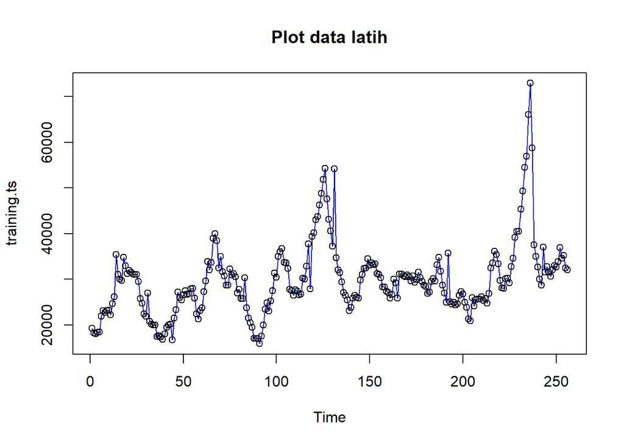

```r
#eksplorasi data latih
plot(training.ts, col="blue",main="Plot data latih")
points(training.ts)
```

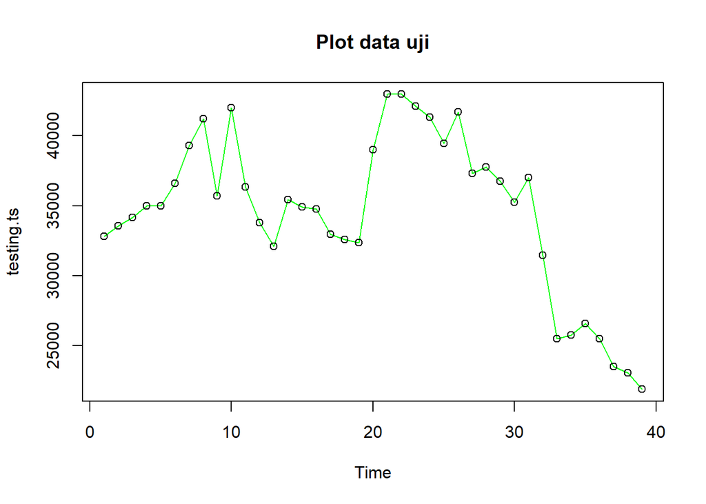

```r
#eksplorasi data uji
plot(testing.ts, col="green",main="Plot data uji")
points(testing.ts)
```

## Single Moving Average (SMA)

Ide dasar dari Single Moving Average (SMA) adalah data suatu periode dipengaruhi oleh data periode sebelumnya. Metode pemulusan ini cocok digunakan untuk pola data stasioner atau konstan. Prinsip dasar metode pemulusan ini adalah data pemulusan pada periode ke-t merupakan rata rata dari m buah data pada periode ke-t hingga periode ke (t-m+1). Data pemulusan pada periode ke-t selanjutnya digunakan sebagai nilai peramalan pada periode ke t+1

Pemulusan dengan parameter `m=2`

```r
data.sma<-SMA(training.ts, n=2)
data.sma
```

```
## Time Series:
## Start = 1
## End = 256
## Frequency = 1
##   [1]    NA 18800 18150 18175 18425 20200 22525 22925 22900 23175 22750 23450
##  [13] 25400 30800 33225 30500 29875 32250 33875 32100 31550 31700 31300 31050
##  [25] 31000 30250 27625 25225 23575 22200 24475 23900 20475 20075 20000 18700
##  [37] 17525 17500 17100 17450 18775 19750 20100 18475 19125 22400 25250 26600
##  [49] 25750 26050 27025 27050 26775 27400 27950 26925 24125 21825 22175 23425
##  [61] 25525 28475 31775 33000 32900 36350 39500 39200 35425 33725 33300 31150
##  [73] 29700 28725 30500 31575 31050 30850 28725 27375 26775 25750 28025 27000
##  [85] 22600 21000 20000 18250 17000 17000 16450 16700 18750 21725 24150 23925
##  [97] 24125 26375 29400 30850 32700 35525 36400 35225 33650 33000 30100 27625
## [109] 26975 27075 27500 26950 26650 28475 30100 31450 35325 32825 33650 39800
## [121] 41600 43375 45000 47500 50300 53050 50900 45325 41825 38900 45725 44425
## [133] 33350 31750 30450 28250 26775 26000 24325 23475 24825 26175 26275 25950
## [145] 27825 30400 31700 32450 33500 33775 33325 33400 33300 32325 31125 30675
## [157] 29300 28250 27800 27200 26450 26275 28375 29650 27550 28500 31150 30950
## [169] 30625 30700 30700 30075 30200 30025 29600 30700 30900 29900 29125 28575
## [181] 27625 27000 28350 29850 29900 31400 33950 33225 30200 27850 26000 30375
## [193] 30400 24775 24700 24600 24450 25550 26875 27000 25875 24400 22550 21100
## [205] 23425 25050 24850 25625 25675 25925 25800 25575 25250 25825 29675 33000
## [217] 34850 35775 34375 31525 28875 28025 29050 30150 29725 31025 33700 36875
## [229] 39825 40500 42925 47300 51875 55700 61450 69450 65825 48125 36250 33850
## [241] 31375 29400 32875 34275 32175 32175 31075 31350 32525 32800 33250 35375
## [253] 35725 34850 33825 32275
```

```r
data.ramal<-c(NA,data.sma)
data.ramal #forecast 1 periode ke depan
```

```
##   [1]    NA    NA 18800 18150 18175 18425 20200 22525 22925 22900 23175 22750
##  [13] 23450 25400 30800 33225 30500 29875 32250 33875 32100 31550 31700 31300
##  [25] 31050 31000 30250 27625 25225 23575 22200 24475 23900 20475 20075 20000
##  [37] 18700 17525 17500 17100 17450 18775 19750 20100 18475 19125 22400 25250
##  [49] 26600 25750 26050 27025 27050 26775 27400 27950 26925 24125 21825 22175
##  [61] 23425 25525 28475 31775 33000 32900 36350 39500 39200 35425 33725 33300
##  [73] 31150 29700 28725 30500 31575 31050 30850 28725 27375 26775 25750 28025
##  [85] 27000 22600 21000 20000 18250 17000 17000 16450 16700 18750 21725 24150
##  [97] 23925 24125 26375 29400 30850 32700 35525 36400 35225 33650 33000 30100
## [109] 27625 26975 27075 27500 26950 26650 28475 30100 31450 35325 32825 33650
## [121] 39800 41600 43375 45000 47500 50300 53050 50900 45325 41825 38900 45725
## [133] 44425 33350 31750 30450 28250 26775 26000 24325 23475 24825 26175 26275
## [145] 25950 27825 30400 31700 32450 33500 33775 33325 33400 33300 32325 31125
## [157] 30675 29300 28250 27800 27200 26450 26275 28375 29650 27550 28500 31150
## [169] 30950 30625 30700 30700 30075 30200 30025 29600 30700 30900 29900 29125
## [181] 28575 27625 27000 28350 29850 29900 31400 33950 33225 30200 27850 26000
## [193] 30375 30400 24775 24700 24600 24450 25550 26875 27000 25875 24400 22550
## [205] 21100 23425 25050 24850 25625 25675 25925 25800 25575 25250 25825 29675
## [217] 33000 34850 35775 34375 31525 28875 28025 29050 30150 29725 31025 33700
## [229] 36875 39825 40500 42925 47300 51875 55700 61450 69450 65825 48125 36250
## [241] 33850 31375 29400 32875 34275 32175 32175 31075 31350 32525 32800 33250
## [253] 35375 35725 34850 33825 32275
```

Peramalan sebanyak data uji yaitu 39 periode.

```r
data.gab<-cbind(aktual=c(training.ts,rep(NA,39)),pemulusan=c(data.sma,rep(NA,39)),ramalan=c(data.ramal,rep(data.ramal[length(data.ramal)],38)))
data.gab #forecast 24 periode ke depan
```

```
##        aktual pemulusan ramalan
##   [1,]  19300        NA      NA
##   [2,]  18300     18800      NA
##   [3,]  18000     18150   18800
##   [4,]  18350     18175   18150
##   [5,]  18500     18425   18175
##   [6,]  21900     20200   18425
##   [7,]  23150     22525   20200
##   [8,]  22700     22925   22525
##   [9,]  23100     22900   22925
##  [10,]  23250     23175   22900
##  [11,]  22250     22750   23175
##  [12,]  24650     23450   22750
##  [13,]  26150     25400   23450
##  [14,]  35450     30800   25400
```

[output cut: 281 more lines]

Adapun plot data deret waktu dari hasil peramalan yang dilakukan adalah sebagai berikut.

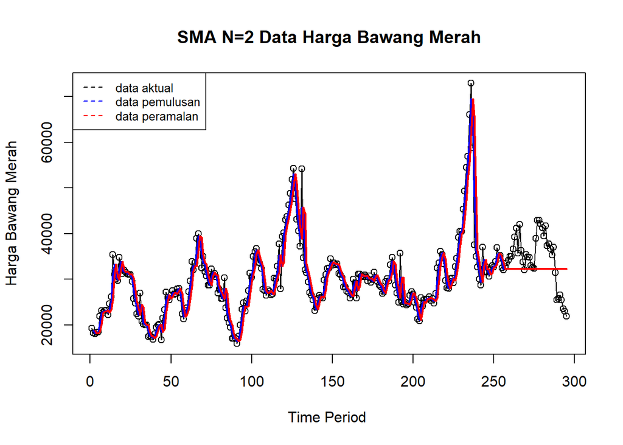

```r
ts.plot(data.ts, xlab="Time Period ", ylab="Harga Bawang Merah", main= "SMA N=2 Data Harga Bawang Merah")
points(data.ts)
lines(data.gab[,2],col="blue",lwd=2)
lines(data.gab[,3],col="red",lwd=2)
legend("topleft",c("data aktual","data pemulusan","data peramalan"), lty=8, col=c("black","blue","red"), cex=0.8)
```

### perhitungan akurasi

Selanjutnya perhitungan akurasi dilakukan dengan ukuran akurasi *Sum Squares Error* (SSE), *Mean Square Error* (MSE) dan *Mean Absolute Percentage Error* (MAPE). Perhitungan akurasi dilakukan baik pada data latih maupun pada data uji.

```r
#Menghitung nilai keakuratan data latih
error_train.sma = training.ts-data.ramal[1:length(training.ts)]
SSE_train.sma = sum(error_train.sma[3:length(training.ts)]^2)
MSE_train.sma = mean(error_train.sma[3:length(training.ts)]^2)
MAPE_train.sma = mean(abs((error_train.sma[3:length(training.ts)]/training.ts[3:length(training.ts)])*100))

akurasi_train.sma <- matrix(c(SSE_train.sma, MSE_train.sma, MAPE_train.sma))
row.names(akurasi_train.sma)<- c("SSE", "MSE", "MAPE")
colnames(akurasi_train.sma) <- c("Akurasi m = 2")
akurasi_train.sma
```

```
##      Akurasi m = 2
## SSE   3.991195e+09
## MSE   1.571337e+07
## MAPE  8.399070e+00
```

Dalam hal ini nilai MAPE data latih pada metode pemulusan SMA kurang dari 10%, nilai ini dapat dikategorikan sebagai nilai akurasi yang sangat baik. Selanjutnya dilakukan perhitungan nilai MAPE data uji pada metode pemulusan SMA.

```r
#Menghitung nilai keakuratan data uji
error_test.sma = testing.ts-data.gab[257:295,3]
SSE_test.sma = sum(error_test.sma^2)
MSE_test.sma = mean(error_test.sma^2)
MAPE_test.sma = mean(abs((error_test.sma/testing.ts*100)))

akurasi_test.sma <- matrix(c(SSE_test.sma, MSE_test.sma, MAPE_test.sma))
row.names(akurasi_test.sma)<- c("SSE", "MSE", "MAPE")
colnames(akurasi_test.sma) <- c("Akurasi m = 2")
akurasi_test.sma
```

```
##      Akurasi m = 2
## SSE   1.451774e+09
## MSE   3.722498e+07
## MAPE  1.526093e+01
```

## Single Exponential Smoothing (SES)

Single Exponential Smoothing merupakan metode pemulusan yang tepat digunakan untuk data dengan pola stasioner atau konstan.

Nilai parameter $\lambda$ adalah nilai antara 0 dan 1. Nilai pemulusan periode ke-t bertindak sebagai nilai ramalan pada periode ke-$(T+\tau)$.

nilai parameter $\lambda$ dengan nilai `alpha` 0,2 dan 0,7

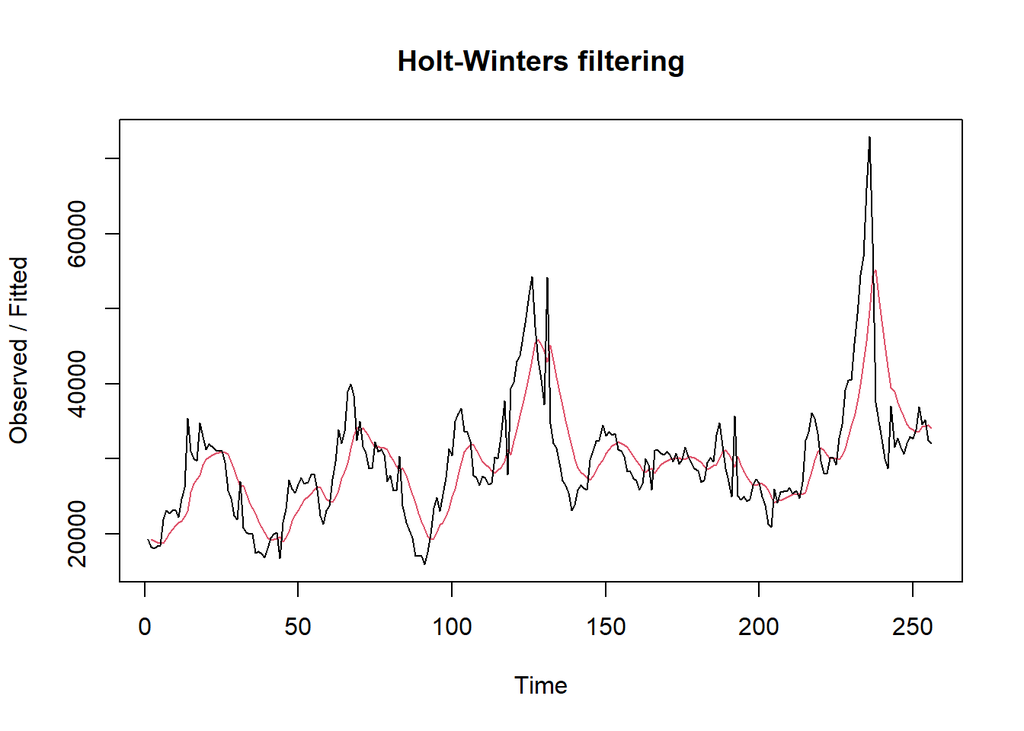

```r
ses1<- HoltWinters(training.ts, gamma = FALSE, beta = FALSE, alpha = 0.2)
plot(ses1)
```

```r
#ramalan
ramalan1<- forecast(ses1, h=39)
ramalan1
```

```
##     Point Forecast    Lo 80    Hi 80    Lo 95    Hi 95
## 257       33699.24 26683.80 40714.68 22970.05 44428.43
## 258       33699.24 26544.87 40853.61 22757.57 44640.91
## 259       33699.24 26408.58 40989.90 22549.14 44849.34
## 260       33699.24 26274.80 41123.68 22344.53 45053.95
## 261       33699.24 26143.38 41255.10 22143.55 45254.93
## 262       33699.24 26014.21 41384.27 21946.00 45452.48
## 263       33699.24 25887.18 41511.30 21751.72 45646.76
## 264       33699.24 25762.18 41636.30 21560.55 45837.93
## 265       33699.24 25639.11 41759.37 21372.34 46026.14
## 266       33699.24 25517.90 41880.58 21186.96 46211.52
## 267       33699.24 25398.46 42000.02 21004.29 46394.19
## 268       33699.24 25280.71 42117.77 20824.21 46574.27
## 269       33699.24 25164.59 42233.89 20646.62 46751.86
## 270       33699.24 25050.03 42348.45 20471.41 46927.07
```

[output cut: 25 more lines]

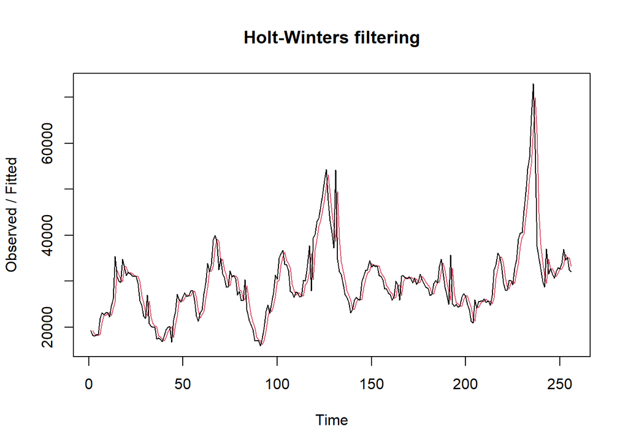

```r
ses2<- HoltWinters(training.ts, gamma = FALSE, beta = FALSE, alpha = 0.7)
plot(ses2)
```

```r
#ramalan
ramalan2<- forecast(ses2, h=39)
ramalan2
```

```
##     Point Forecast    Lo 80    Hi 80       Lo 95    Hi 95
## 257       32418.04 27626.60 37209.47 25090.17095 39745.90
## 258       32418.04 26569.35 38266.73 23473.23662 41362.84
## 259       32418.04 25675.89 39160.18 22106.81560 42729.26
## 260       32418.04 24887.71 39948.37 20901.39168 43934.68
## 261       32418.04 24174.54 40661.53 19810.69976 45025.37
## 262       32418.04 23518.34 41317.73 18807.13017 46028.94
## 263       32418.04 22907.31 41928.76 17872.63851 46963.43
## 264       32418.04 22333.24 42502.84 16994.66351 47841.41
## 265       32418.04 21790.12 43045.95 16164.04418 48672.03
## 266       32418.04 21273.45 43562.63 15373.85574 49462.22
## 267       32418.04 20779.68 44056.39 14618.71265 50217.36
## 268       32418.04 20306.03 44530.04 13894.32841 50941.74
## 269       32418.04 19850.22 44985.85 13197.22504 51638.85
## 270       32418.04 19410.37 45425.70 12524.53443 52311.54
```

[output cut: 25 more lines]

Nilai parameter $\alpha$ dari kedua fungsi dapat dioptimalkan menyesuaikan dari *error*-nya paling minimumnya. Caranya adalah dengan membuat parameter $\alpha =$ `NULL` .

```r
#Lamda Optimum Holt Winter
sesopt<- HoltWinters(training.ts, gamma = FALSE, beta = FALSE,alpha = NULL)
sesopt
```

```
## Holt-Winters exponential smoothing without trend and without seasonal component.
##
## Call:
## HoltWinters(x = training.ts, alpha = NULL, beta = FALSE, gamma = FALSE)
##
## Smoothing parameters:
##  alpha: 0.952375
##  beta : FALSE
##  gamma: FALSE
##
## Coefficients:
##       [,1]
## a 32077.39
```

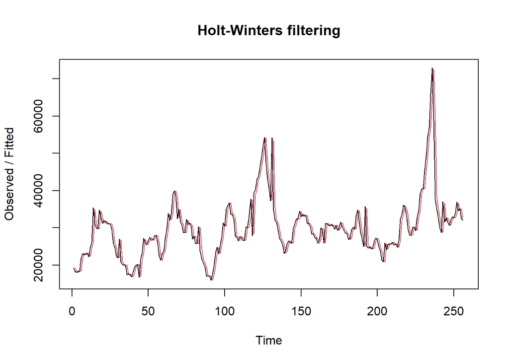

```r
plot(sesopt)
```

```r
#ramalan
ramalanopt<- forecast(sesopt, h=39)
ramalanopt
```

```
##     Point Forecast     Lo 80    Hi 80       Lo 95    Hi 95
## 257       32077.39 27447.956 36706.82  24997.2832 39157.49
## 258       32077.39 25684.382 38470.39  22300.1295 41854.65
## 259       32077.39 24311.475 39843.30  20200.4488 43954.33
## 260       32077.39 23147.198 41007.58  18419.8412 45734.94
## 261       32077.39 22118.112 42036.66  16845.9900 47308.79
## 262       32077.39 21185.829 42968.95  15420.1858 48734.59
## 263       32077.39 20327.284 43827.49  14107.1546 50047.62
## 264       32077.39 19527.335 44627.44  12883.7383 51271.04
## 265       32077.39 18775.407 45379.37  11733.7627 52421.01
## 266       32077.39 18063.766 46091.01  10645.4028 53509.37
## 267       32077.39 17386.558 46768.22   9609.7025 54545.07
## 268       32077.39 16739.221 47415.56   8619.6858 55535.09
## 269       32077.39 16118.120 48036.66   7669.7930 56484.98
## 270       32077.39 15520.301 48634.48   6755.5082 57399.27
```

[output cut: 25 more lines]

#### Akurasi Data Latih

```r
#Pada data training
SSE1<-ses1$SSE
MSE1<-ses1$SSE/length(training.ts)
RMSE1<-sqrt(MSE1)

akurasi1 <- matrix(c(SSE1,MSE1,RMSE1))
row.names(akurasi1)<- c("SSE", "MSE", "RMSE")
colnames(akurasi1) <- c("Akurasi lamda=0.2")
akurasi1
```

```
##      Akurasi lamda=0.2
## SSE       7.631845e+09
## MSE       2.981189e+07
## RMSE      5.460027e+03
```

```r
SSE2<-ses2$SSE
MSE2<-ses2$SSE/length(training.ts)
RMSE2<-sqrt(MSE2)

akurasi2 <- matrix(c(SSE2,MSE2,RMSE2))
row.names(akurasi2)<- c("SSE", "MSE", "RMSE")
colnames(akurasi2) <- c("Akurasi lamda=0.7")
akurasi2
```

```
##      Akurasi lamda=0.7
## SSE       3.551902e+09
## MSE       1.387462e+07
## RMSE      3.724865e+03
```

```r
SSEopt<-sesopt$SSE
MSEopt<-sesopt$SSE/length(training.ts)
RMSEopt<-sqrt(MSEopt)

akurasiopt <- matrix(c(SSEopt,MSEopt,RMSEopt))
row.names(akurasiopt)<- c("SSE", "MSE", "RMSE")
colnames(akurasiopt) <- c("opt")
akurasiopt
```

```
##               opt
## SSE  3.315198e+09
## MSE  1.294999e+07
## RMSE 3.598610e+03
```

#### Akurasi Data Uji

```r
selisih1<-ramalan1$mean-testing
SSEtesting1<-sum(selisih1^2)
MSEtesting1<-SSEtesting1/length(testing)

selisih2<-ramalan2$mean-testing
SSEtesting2<-sum(selisih2^2)
MSEtesting2<-SSEtesting2/length(testing)

selisihopt<-ramalanopt$mean-testing
SSEtestingopt<-sum(selisihopt^2)
MSEtestingopt<-SSEtestingopt/length(testing)

akurasitesting1 <- matrix(c(SSEtesting1,SSEtesting2,SSEtestingopt))
row.names(akurasitesting1)<- c("SSE1", "SSE2", "SSEopt")
akurasitesting1
```

```
##              [,1]
## SSE1   1278580156
## SSE2   1427233346
## SSEopt 1488304241
```

```r
akurasitesting2 <- matrix(c(MSEtesting1,MSEtesting2,MSEtestingopt))
row.names(akurasitesting2)<- c("MSE1", "MSE2", "MSEopt")
akurasitesting2
```

```
##            [,1]
## MSE1   32784107
## MSE2   36595727
## MSEopt 38161647
```

```r
MAPEtesting1 = mean(abs((selisih1/testing*100)))
MAPEtesting2 = mean(abs((selisih2/testing*100)))
MAPEtestingopt = mean(abs((selisihopt/testing*100)))

akurasitesting3 <- matrix(c(MAPEtesting1,MAPEtesting2,MAPEtestingopt))
row.names(akurasitesting3)<- c("MAPE1", "MAPE2", "MAPEopt")
akurasitesting3
```

```
##             [,1]
## MAPE1   14.22505
## MAPE2   15.10071
## MAPEopt 15.50079
```

### Perbandingan Metode

```r
perbandingan_metode <-
  matrix(c(SSE_test.sma, MSE_test.sma, MAPE_test.sma, SSEtesting1,MSEtesting1,MAPEtesting1),
         nrow=3,ncol=2)
row.names(perbandingan_metode)<- c("SSE", "MSE", "MAPE")
colnames(perbandingan_metode) <- c("SMA","SES")
perbandingan_metode
```

```
##               SMA          SES
## SSE  1.451774e+09 1.278580e+09
## MSE  3.722498e+07 3.278411e+07
## MAPE 1.526093e+01 1.422505e+01
```

Berdasarkan nilai SSE, MSE, dan MAPE, metode SES dengan n=0.2 lebih baik karena memiliki ukuran kesalahan yang lebih kecil dibandingkan lainnya. Berdasarkan nilai MAPE sebesar 14.22%, metode tersebut memberikan peramalan dengan akurasi yang baik.